# Composition Analysis of Norwegian National Bibliography dated 2026-03-10

# Overall summary

2,260,187 records and 146,707,710 attribute values in total. Constituent files:

- data/natno/natno.parquet (350MB)

## Temporal overview

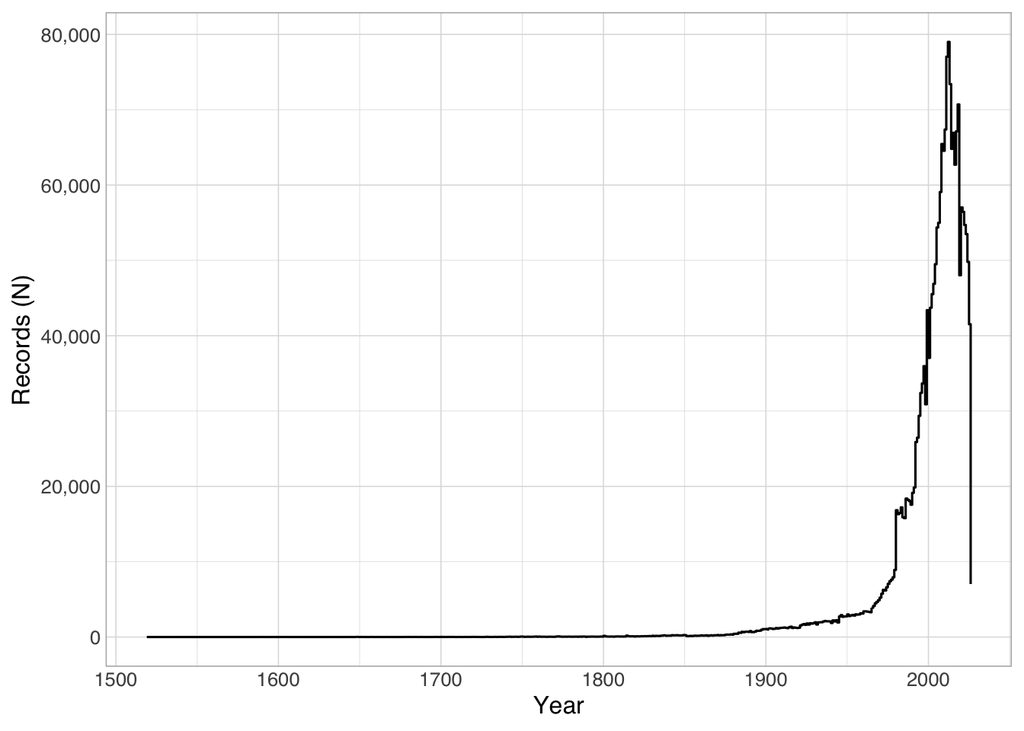

21,358 records do not have easily parseable dates between the years 1000 and 2050.

## Language overview

| [] | Records (N) | Proportion (%) |
| --- | --- | --- |
| nob (Bokmål, Norwegian; Norwegian Bokmål) | 1133131 | 0.50134169720604 |
| und (Undetermined) | 381039 | 0.168586632050215 |
| eng (English) | 328446 | 0.145317421446007 |
| nno (Norwegian Nynorsk; Nynorsk, Norwegian) | 102632 | 0.0454084312119696 |
| nor (Norwegian) | 90415 | 0.0400031501678836 |
| zxx (No linguistic content; Not applicable) | 64840 | 0.0286877648275792 |
| mul (Multiple languages) | 56086 | 0.0248146511122703 |
| swe (Swedish) | 24361 | 0.0107782640185789 |
| dan (Danish) | 23530 | 0.0104105969523895 |
| ger (German) | 11523 | 0.00509822816329727 |

[output cut: 177 more lines]

# Field code usage overview

In total, 342 distinct fields are used.

Legend for the table below:

- `records`: how many records have at least one of this field
- `r_p`: the above as a percentage of all records
- `n`: the total number of appearances of this field
- `vals_per_rec`: calculated from the above, the mean number of appearances of this field per record
- `recs_with_mult_vals`: the number of records that have more than one repetition of this field

| field_code | field_description | records | r_p | n | vals_per_rec | recs_with_mult_vals |
| --- | --- | --- | --- | --- | --- | --- |
| <a name=""></a> | NA | 7 | 3.09708886919534e-06 | 16 | 2.28571428571429 | 3 |
| <a name="$$G">$$G</a> | NA | 1 | 4.42441267027905e-07 | 44 | 44 | 1 |
| <a name="$4G">$4G</a> | NA | 1 | 4.42441267027905e-07 | 43 | 43 | 1 |
| <a name="+92">+92</a> | NA | 1 | 4.42441267027905e-07 | 2 | 2 | 1 |
| <a name="000">000</a> | NA | 2 | 8.8488253405581e-07 | 2 | 1 | 0 |
| <a name="001" href="https://www.loc.gov/marc/bibliographic/bd001.html">001</a> | Control Number | 2260187 | 1 | 2260187 | 1 | 0 |
| <a name="004">004</a> | NA | 3 | 1.32732380108372e-06 | 3 | 1 | 0 |
| <a name="005" href="https://www.loc.gov/marc/bibliographic/bd005.html">005</a> | Date and Time of Latest Transaction | 2254962 | 0.997688244379779 | 2254962 | 1 | 0 |
| <a name="006" href="https://www.loc.gov/marc/bibliographic/bd006.html">006</a> | Additional Material Characteristics | 4 | 1.76976506811162e-06 | 4 | 1 | 0 |
| <a name="007" href="https://www.loc.gov/marc/bibliographic/bd007.html">007</a> | Physical Description | 2258656 | 0.99932262242018 | 3065840 | 1.35737358854115 | 807108 |

[output cut: 332 more lines]

# Field code usage overview by subfield

In total, 2,315 distinct field+subfield combinations are used.

Legend for the table below:

- `records`: how many records have at least one of this field+subfield
- `r_p`: the above as a percentage of all records
- `dist_vals`: the number of different values appearing in this field+subfield
- `e_vals`: at most seven random sample values of this field+subfield
- `n`: the total number of appearances of this field+subfield
- `vals_per_rec`: calculated from the above, the mean number of appearances of this field+subfield per record
- `recs_with_mult_vals`: the number of records that have more than one repetition of this field+subfield

| subfield_code | subfield_description | records | r_p | dist_vals | e_vals | n | vals_per_rec | recs_with_mult_vals |
| --- | --- | --- | --- | --- | --- | --- | --- | --- |
| : NA |  |  |  |  |  |  |  |  |
| $Y | NA | 1 | 0% | 1 | 1 (1) | 1 | 1 | 0 |
| $a | NA | 7 | 0% | 14 | Nilssen-Love, Paal (1)\|Opplagshistorikk: 3. oppl. 1992 (1)\|skattejakt (1)\|kristendom (1)\|ungdomsbøker (1)\|arv (1)\|spenning (1) | 14 | 2 | 1 |
| $q | NA | 1 | 0% | 1 | h. (1) | 1 | 1 | 0 |
| $$G: NA |  |  |  |  |  |  |  |  |
| $$G$Y | NA | 1 | 0% | 1 | F (1) | 1 | 1 | 0 |
| $$G$Z | NA | 1 | 0% | 1 | o (1) | 1 | 1 | 0 |
| $$G$g | NA | 1 | 0% | 15 | 12.: (1)\|Forord.- (1)\|11.: (1)\|3.: (1)\|8.: (1)\|Referanser (1)\|2.: (1) | 15 | 15 | 1 |
| $$G$r | NA | 1 | 0% | 7 | Pål Riis,. - (1)\|Jan Merok Paulsen.- (2)\|Pål Riis.- (6)\|Jan Merok Paulsen. - (1)\|Jan Merok Paulsen, og (4)\|Pål Riis.,- (1)\|Pål Riis,og (1) | 16 | 16 | 1 |
| $$G$t | NA | 1 | 0% | 11 | Praksisforbedringer gjennom utprøving og implementering / (1)\|Ledelse gjennom barnehagens ledergruppe / (1)\|Dialogens betydning i lærende organisasjoner / (1)\|Metodebank for kollektiv læring i barn… | 11 | 11 | 1 |
| $4G: NA |  |  |  |  |  |  |  |  |
| $4G$Y | NA | 1 | 0% | 1 | 1 (1) | 1 | 1 | 0 |
| $4G$Z | NA | 1 | 0% | 1 | . (1) | 1 | 1 | 0 |
| $4G$g | NA | 1 | 0% | 24 | Å tegne fremtidens lerret : scenarioanalyse ; (1)\|Litteratur.- (1)\|Ordliste.- (1)\|Forfatterpresentasjoner (1)\|11.. (1)\|8.: (1)\|4.: (1) | 24 | 24 | 1 |
| $4G$t | NA | 1 | 0% | 17 | Kausaldiagramanalyse : kongen på haugen ; (1)\|Kjendisen i gjengen : SWOT (og TOWS) - ; (1)\|Hva er egentlig data? ; (1)\|Om etterretningsanalyse : (1)\|Når fienden faller som et korthus : tyngdepunkt… | 17 | 17 | 1 |
| +92: NA |  |  |  |  |  |  |  |  |
| +92$2 | NA | 1 | 0% | 1 | misklass (1) | 1 | 1 | 0 |
| +92$a | NA | 1 | 0% | 1 | PT 92 (1) | 1 | 1 | 0 |
| 000: NA |  |  |  |  |  |  |  |  |
| 000$ | NA | 2 | 0% | 1 | nam a22 5c 4500 (2) | 2 | 1 | 0 |
| [001: Control Number](https://www.loc.gov/marc/bibliographic/bd001.html) |  |  |  |  |  |  |  |  |
| 001$ | NA | 2,260,187 | 100% | 2,260,187 | 999921695739902201 (1)\|991331194914702201 (1)\|999921697363802201 (1)\|999921732785202201 (1)\|999921753240002201 (1)\|999621439014702201 (1)\|999921130705702201 (1) | 2,260,187 | 1 | 0 |
| 004: NA |  |  |  |  |  |  |  |  |
| 004$ | NA | 3 | 0% | 3 | 832096687-47bibsys_skofimus (1)\|150172508-47bibsys_khib (1)\|862091659-47bibsys_skofimus (1) | 3 | 1 | 0 |
| [005: Date and Time of Latest Transaction](https://www.loc.gov/marc/bibliographic/bd005.html) |  |  |  |  |  |  |  |  |
| 005$ | NA | 2,254,962 | 99.77% | 575,030 | 20260223225805.0 (72)\|20231230051716.0 (1)\|20230220145321.0 (1)\|20231130052937.0 (1)\|20221027133403.0 (1)\|20250505105447.0 (1)\|20230608104732.0 (3) | 2,254,962 | 1 | 0 |
| [006: Additional Material Characteristics](https://www.loc.gov/marc/bibliographic/bd006.html) |  |  |  |  |  |  |  |  |
| 006$ | NA | 4 | 0% | 2 | $$a Boulez, Pierre $$d 1925-2016 $$0 90059641 (1)\|m \|\| d \| (3) | 4 | 1 | 0 |
| [007: Physical Description](https://www.loc.gov/marc/bibliographic/bd007.html) |  |  |  |  |  |  |  |  |
| 007$ | NA | 2,258,656 | 99.93% | 290 | sd#fs\|g\|\|mm\|ed (115)\|sd#fq\|g\|\|mm\|ed (2)\|kl#ao\| (1)\|sd f\|\|\|\|\|\|\|\|\|\|\|\|\|\|\|\|\|\| (32)\|cr nna\|\|\|\|\|\|\|\| (4,767)\|ss\|k\|\|\|\|\|\|\|\|\|\| (1)\|he#\|\|\|\|\|\|\|\|\|\| (2) | 3,065,840 | 1.36 | 807,108 |

[output cut: 2627 more lines]